# ggplot2 Elegant Graphics for Data Analysis

# 5 Coefficient-Level Summaries

모델 수준 요약에서는 계절성에 중요한 차이가 있다는 것을 의미했다. 좀 더 자세히 알아보기 위해 `tidy()`로 계수를 추출해 보자.

`extract(data, col, into, regex = "([[:alnum:]]+)", remove = TRUE, convert = FALSE, ...)` into : 새로운 변수의 이름 regex : a regular expression

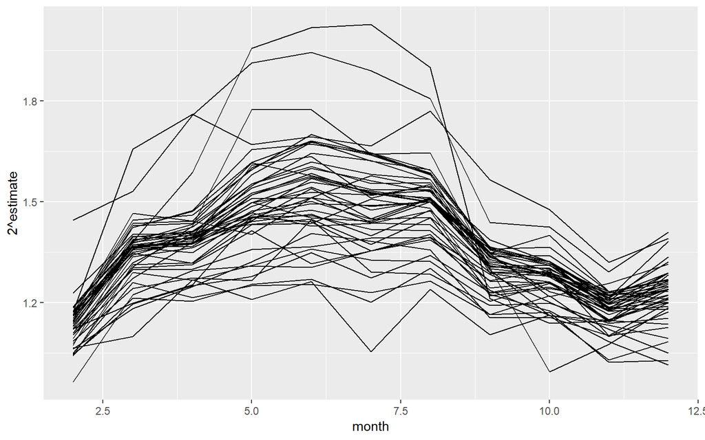

```r
coefs <- models %>% tidy(mod)
months <- coefs %>%
  filter(grepl("factor", term)) %>%
  extract(term, "month", "(\\d+)", convert = TRUE)
ggplot(months, aes(month, 2 ^ estimate)) + #계수를 해석하기 쉽고자
  geom_line(aes(group = city))
```

패턴은 도시별로 비슷해 보이고 주요 차이점은 계절적 영향의 강도이다.

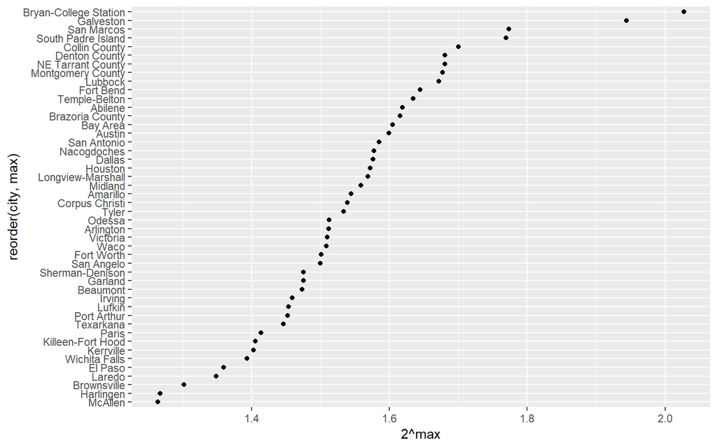

```r
coef_sum <- months %>%
  group_by(city) %>%
  summarise(max = max(estimate))
ggplot(coef_sum, aes(2 ^ max, reorder(city, max))) +
  geom_point()
```

The cities with the strongest seasonal effect are College Station and San Marcos (both college towns) and Galveston and South Padre Island (beach cities). It makes sense that these cities would have very strong seasonal effects. 하지만 왜 계수가 큰 것이 강한 계절적 추세를 의미하는 것일까? 나의 답 : max보다는 mean으로 해야 할 것 같긴 한데..일단 받아 들이고 실험계획법에 따르면 effect는 회귀 계수의 배수.

## 5.1 Exercises

1. Pull out the three cities with highest and lowest seasonal effect. Plot their coefficients.

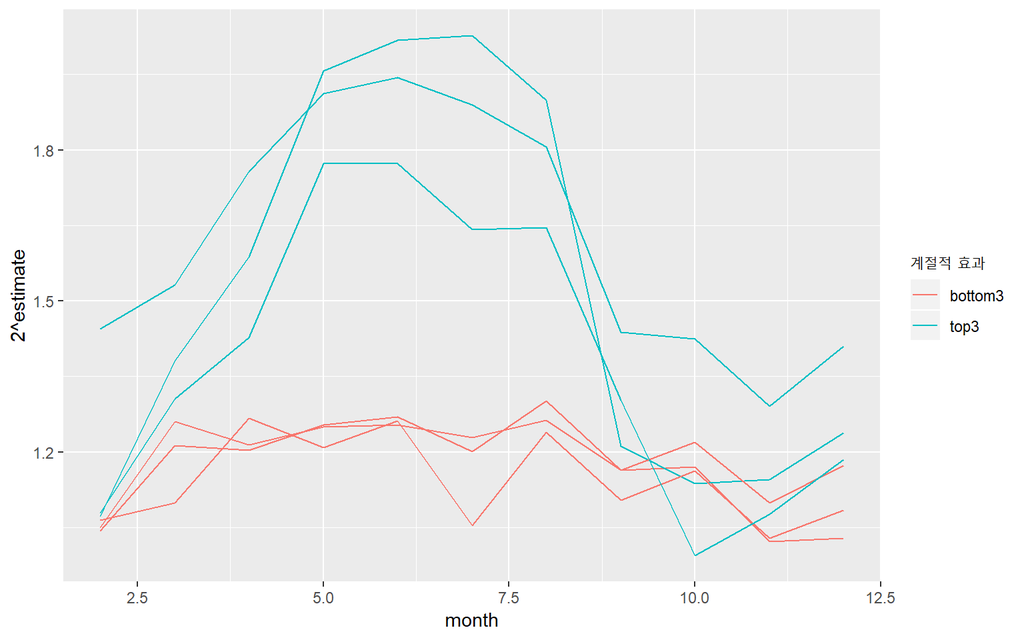

```r
bottom3 <- coef_sum %>%
  arrange(max) %>%
  pull(city) %>%
  head(3)

top3 <- coef_sum %>%
  arrange(desc(max)) %>%
  pull(city) %>%
  head(3)

temp <- coefs %>%
  filter(city %in% c(top3, bottom3), grepl("factor", term)) %>%
  mutate(city_top = ifelse(city %in% top3, "top3", "bottom3")) %>%
  extract(term, "month", "(\\d+)", convert = TRUE)

ggplot(temp, aes(month, 2^estimate, colour = factor(city_top))) +
  geom_line(aes(group = city)) +
  scale_color_discrete("계절적 효과")
```

2. How does strength of seasonal effect relate to the R2 for the model? Answer with a plot.

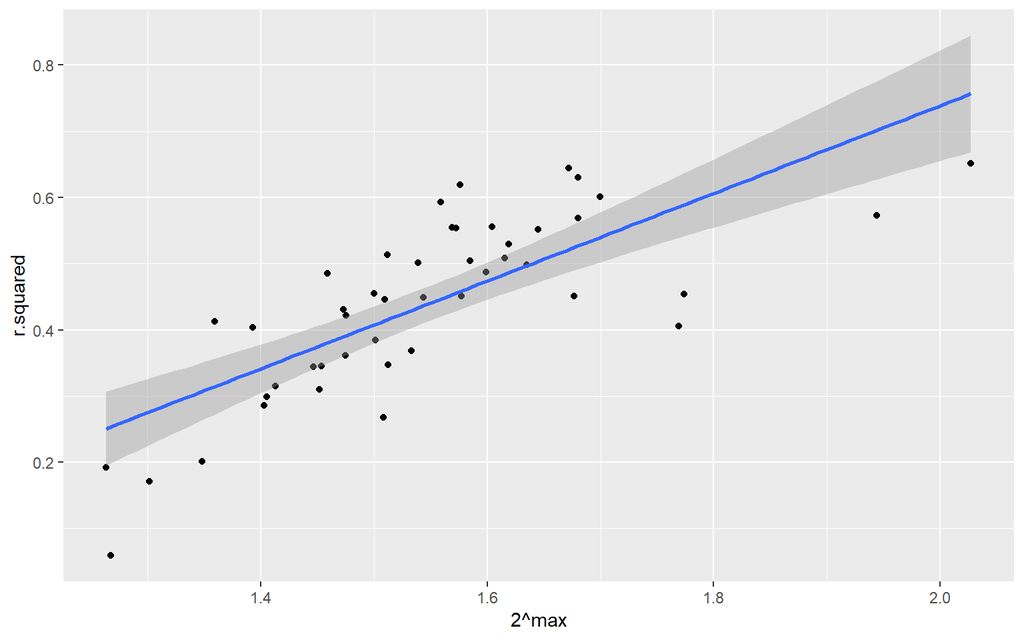

```r
temp <- left_join(model_sum, coef_sum, by = "city")
ggplot(temp, aes(2^max, r.squared)) +
  geom_point() +
  geom_smooth(method = "lm")
```

계절적 추세가 강할수록 R^2도 증가한다.

3. You should be extra cautious when your results agree with your prior beliefs. How can you confirm or refute my hypothesis about the causes of strong seasonal patterns?

내가 생각한 계절적 추세의 강함은 도시의 크기와 비례한다.

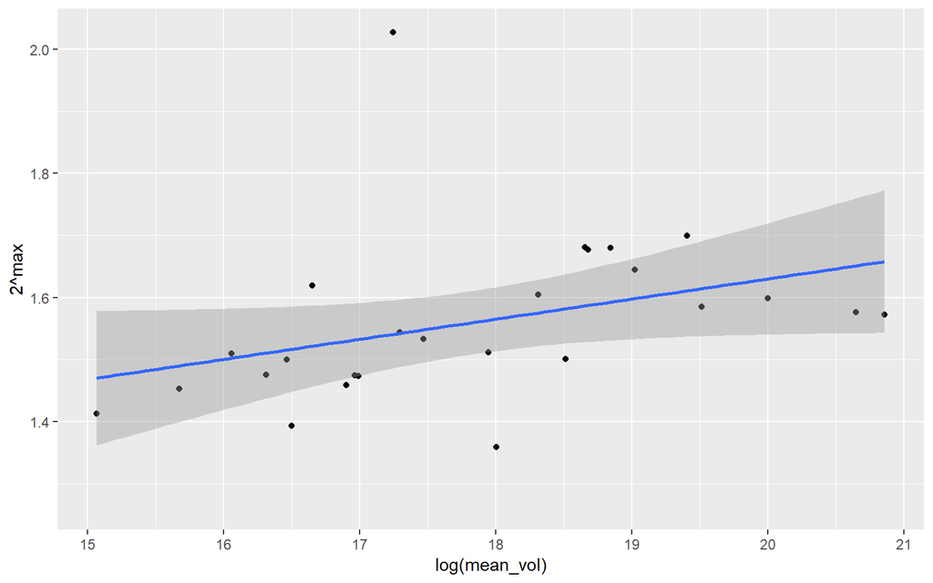

```r
volume <- txhousing %>%
  group_by(city) %>%
  summarise(mean_vol = mean(volume))
temp <- left_join(coef_sum, volume, by = "city")
ggplot(temp, aes(log(mean_vol), 2^max)) +
  geom_point() +
  geom_smooth(method = "lm")
```

이전에 계절적 효과가 가장 큰 도시가 대학 도시와 해변 도시임을 고려했을 때 이런 도시가 실제로 계절적 효과가 큰것인가를 확인 해보고싶지만 txhousing데이터에서 이런 위치에 있는 도시인지를 확인하는 것은 어렵다. 위치를 나타내는 데이터를 추가로 확보해야 한다.

중요!! 4. Group the diamonds data by cut, clarity and colour. Fit a linear model log(price) ~ log(carat). What does the intercept tell you? What does the slope tell you? How do the slope and intercept vary across the groups? Answer with a plot.

절편의 의미는 케럿이 고정되어 있을 때, 품질에 따른 다이아 가격의 차이를 알 수 있고, slope는 품질에 따라 케럿이 커짐에 따라 가격의 높아짐의 정도를 측정할 수 있다(회귀 계수의 의미).

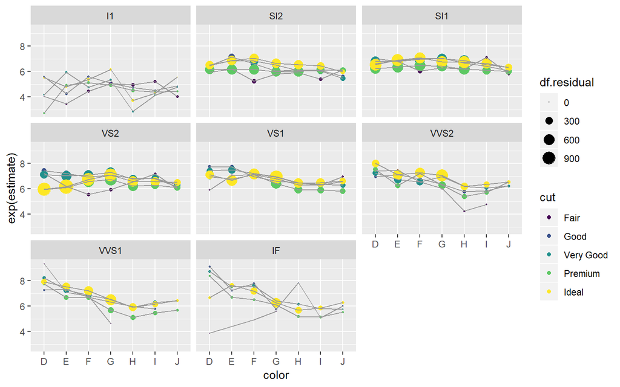

```r
models <- diamonds %>%
  group_by(cut, clarity, color) %>%
  do(mod = lm(
              log(price) ~ log(carat),
              data = .,
              na.action = na.exclude
              )
     )
models_sum <- models %>% glance(mod)
models_coef <- models %>% tidy(mod)

temp <- models_coef %>%
  left_join(models_sum, by = c("cut", "clarity", "color"))

ggplot(filter(temp, term == "log(carat)"), aes(color, exp(estimate))) +
  geom_point(aes(colour = cut, size = df.residual)) +
  geom_line(aes(group = cut), colour = "grey60") +
  facet_wrap(~clarity) +
  scale_size_area()
```

좋은 품질의 다이아의 케럿에 따른 가격의 효과는 품질이 더 좋다고 해서 효과의 크기가 크다고 할 수 없다. 즉, 효과의 크기는 선형성이 없다.

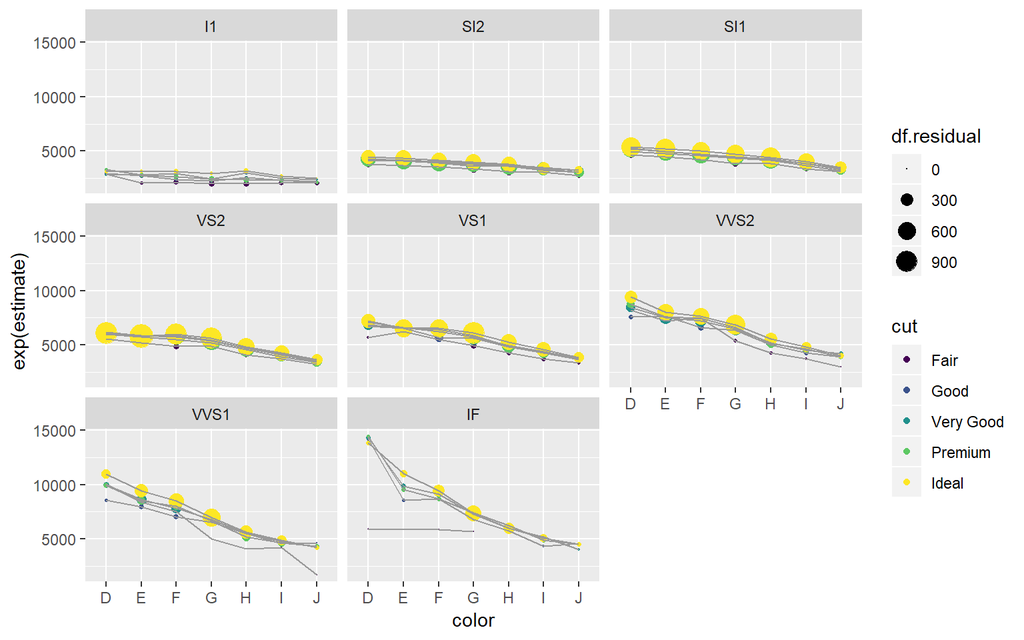

```r
ggplot(filter(temp, term != "log(carat)"), aes(color, exp(estimate))) +
  geom_point(aes(colour = cut, size = df.residual)) +
  geom_line(aes(group = cut), colour = "grey60") +
  facet_wrap(~clarity) +
  scale_size_area()
```

절편은 좋은 품질의 다이아 일수록 가격이 더 비쌈을 의미한다.

결론을 내리면, 좋은 품질의 다이아가 비싸다고 말할 수 있지만 케럿이 커짐에 따라 가격이 비싸지는 정도는 품질에 따라 관련이 없다.

# 6 Observation Data

Observation-level data란 회귀진단을 할 때 유용한 레버리지 포인트, 잔차 등을 포함한 데이터. `augment()`로 추출.

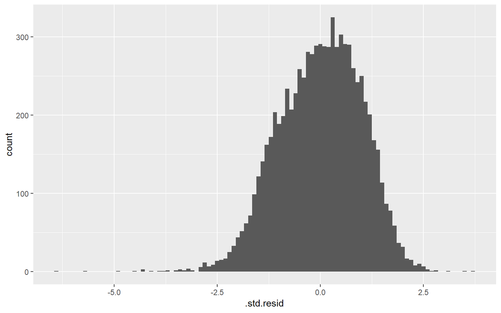

```r
models <- txhousing %>%
group_by(city) %>%
do(mod = lm(
            log2(sales) ~ factor(month),
            data = .,
            na.action = na.exclude
))
model_sum <- models %>% glance(mod) %>%
  arrange(desc(r.squared))
obs_sum <- models %>% augment(mod)

ggplot(obs_sum, aes(.std.resid)) +
geom_histogram(binwidth = 0.1)
```

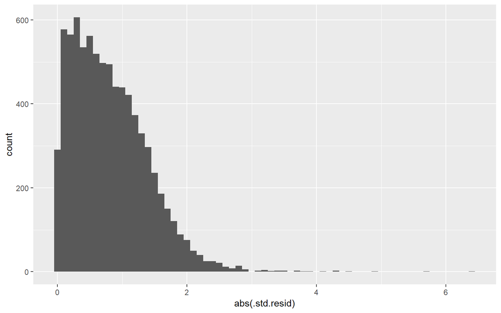

```r
ggplot(obs_sum, aes(abs(.std.resid))) +
geom_histogram(binwidth = 0.1)
```

```r
 obs_sum %>%
 filter(abs(.std.resid) > 2) %>%
 group_by(city) %>%
 summarise(n = n(), avg = mean(abs(.std.resid))) %>%
 arrange(desc(n))
```

```
## # A tibble: 43 x 3
##    city                      n   avg
##    <chr>                 <int> <dbl>
##  1 Texarkana                12  2.43
##  2 Harlingen                11  2.73
##  3 Waco                     11  2.96
##  4 Victoria                 10  2.49
##  5 Brazoria County           9  2.31
##  6 Brownsville               9  2.48
##  7 Bryan-College Station     9  2.27
##  8 Killeen-Fort Hood         9  2.23
##  9 Laredo                    9  2.87
## 10 Nacogdoches               9  2.15
## # ... with 33 more rows
```

## 6.1 Exercises

1. A common diagnostic plot is fitted values (.fitted) vs. residuals (.resid). Do you see any patterns? What if you include the city or month on the same plot?

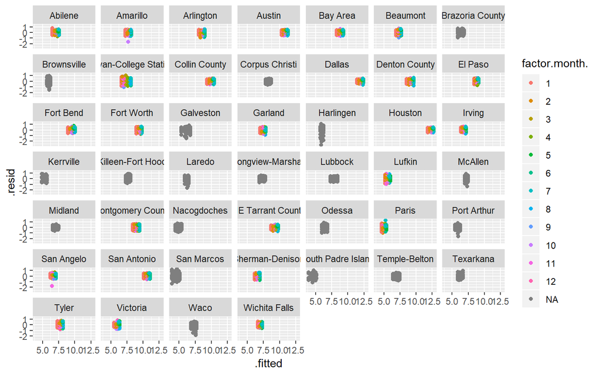

```r
ggplot(obs_sum, aes(.fitted, .resid)) +
  geom_point(aes(colour = factor.month.)) +
  facet_wrap(~city)
```

여름이 적합치가 높음을 알 수 있다.

2. Create a time series of log(sales) for each city. Highlight points that have a standardised residual of greater than 2.

```r
temp <- left_join(txhousing, obs_sum, by = "city")
temp$outlier <- ifelse(abs(temp$.std.resid) > 2, 1, 0)
sum(temp$outlier)
```

```
## [1] 50116
```

```r
nrow(temp)
```

```
## [1] 1502358
```

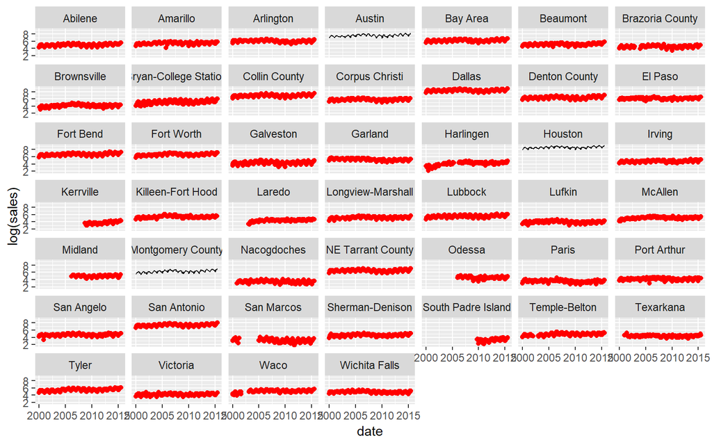

```r
ggplot(temp, aes(date, log(sales))) +
   geom_line() +
   geom_point(data = filter(temp, outlier==1), colour = "red") +
   facet_wrap(~city)
```

150만개의 관측치 중에 5만개가 outlier로 의심되는 상황이다. 지나치게 점들이 많아서 빨갛게 보인다..

# 7 Bonus

```
## Warning: Removed 1 rows containing missing values (geom_crossbar).
```

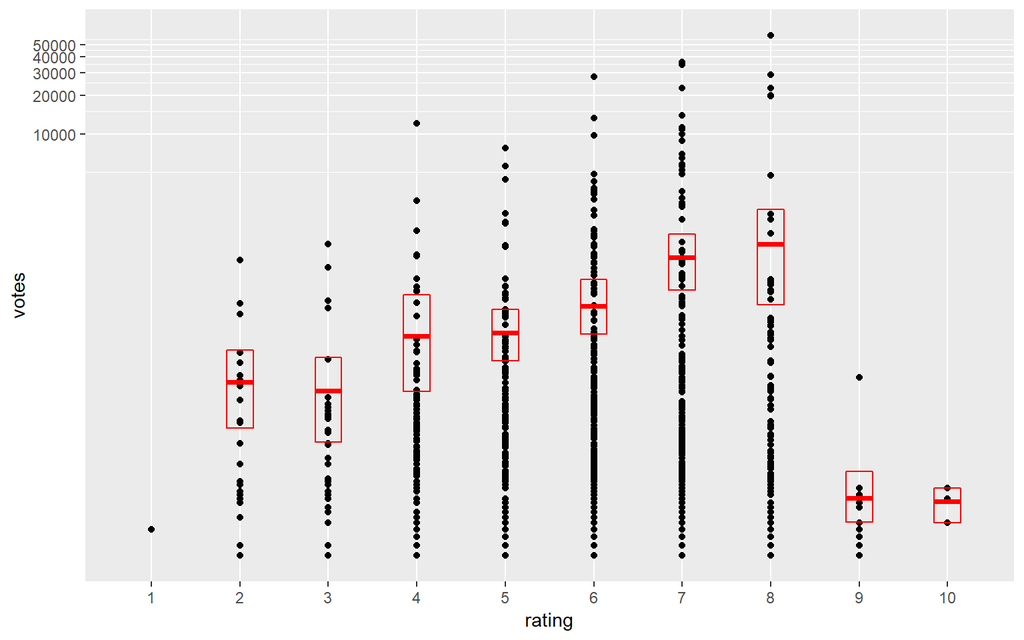

```r
# An example with highly skewed distributions:
if (require("ggplot2movies")) {
  set.seed(596)
  mov <- movies[sample(nrow(movies), 1000), ]
  m2 <- ggplot(mov, aes(x = factor(round(rating)), y = votes)) + geom_point()
  m2 <- m2 + stat_summary(fun.data = "mean_cl_boot", geom = "crossbar",
                          colour = "red", width = 0.3) + xlab("rating")
  m2
  # Notice how the overplotting skews off visual perception of the mean
  # supplementing the raw data with summary statistics is _very_ important

  # Next, we'll look at votes on a log scale.

  # Transforming the scale means the data are transformed
  # first, after which statistics are computed:
  m2 + scale_y_log10()
  # Transforming the coordinate system occurs after the
  # statistic has been computed. This means we're calculating the summary on the raw data
  # and stretching the geoms onto the log scale.  Compare the widths of the
  # standard errors.
  m2 + coord_trans(y="log10")
}
```

- `require()` : require is designed for use inside other functions; it returns FALSE and gives a warning if the package does not exist.
- `library()` : 로드된 패키지를 문자벡터로 반환. 패키지가 없으면 에러 메세지 반환

# 8 Summary

- removing trend : 가장 강한 추세를 경우에 따라 걷어내자. 상대가격을 통해 추세를 살펴보자.
- backtransformation : 해석을 용이하게 하기 위하여
- 규모에 따른 차이를 제거하기 위해 로그를 취한다.
- 계절적 추세를 제거하기위해 lm(반응변수 ~ factor(month))에서 resid사용
- na.action = na.xclude : NA가 있는 행을 제거하지 않고 NA로 채움.
- 장기적 추세를 확인하는 방법중 하나는 `geom_smooth(method = "lm", formula = y ~ splines::bs(x, df = 15, degree = 3), se = FALSE)`
- lazay-evaluation 대신에 standard-evaluation을 사용하기 위해 `함수이름_`을 사용한다.
- `grepl()`과 `extract()`과 정규표현식 : `"\\d+"`의 사용
- `glance()` : 모형비교의 유용한 $R^2, AIC, BIC, deviation, df.residual, p.value$ 등을 제공
- `tidy()` : 모형의 계수들을 알 수 있다. $estimate, std.error, p.value$
- `augment()` : 회귀진단을 할 때 유용한 $fitted, se.fit, resid, hat, cook's distance, 표준화잔차$